# SR_04_RLTD_ORG_CORP_ADDR_L2

Related organization street address line 2 · Text report

## Overview

**Description**

Address Foreign - AddressLine2

**Table**

`SR-P04-T01-ID-RLTD-ORGS-TAXABLE-CORPORATION` (many)

**Location code**

`SCHED-R-PART-04-COL-A`

**Family**

`SCHED-R-PART-04-COL-A` · siblings: SR_04_RLTD_ORG_CORP_ADDR_CITY, SR_04_RLTD_ORG_CORP_ADDR_CNTR, SR_04_RLTD_ORG_CORP_ADDR_L1, SR_04_RLTD_ORG_CORP_ADDR_STATE, SR_04_RLTD_ORG_CORP_ADDR_ZIP, SR_04_RLTD_ORG_CORP_EIN

**Data type**

text (xsd: StreetAddressType)

**Scope**

PC

**Status**

unreviewed

6

xpaths mapped (6 observed)

7,369

filings with a value

2009–2024

tax years observed

3

open flags (1 errors)

## Flags

| Severity | Flag | Xpath | Detail |
| --- | --- | --- | --- |
| ⚠ error | `COLLISION` | IRS990ScheduleR/IdRelatedOrgTxblCorpTrGrp/ForeignAddress/AddressLine2Txt | 1640 filings contain 2+ of its xpaths; most common set: /Return/ReturnData/IRS990ScheduleR/IdRelatedOrgTxblCorpTrGrp/ForeignAddress/AddressLine2Txt ; /Return/ReturnData/IRS990ScheduleR/IdRelatedOrgTxb… |
| ▲ warn | `INCIDENCE_BREAK` |  | 990 fill rate changes up to 3.2x year-on-year (in 2018) |
| ⓘ info | `MANY_NOT_REPEATING` | IRS990ScheduleR/Form990ScheduleRPartIV/AddressForeign/AddressLine2 | many-to-one table, but 68% of values sit in no repeating element |

## Xpaths

All mapped xpaths (under /Return/ReturnData or /Return/ReturnHeader), oldest first. Charts label each series by its xpath.

| Xpath | Form | Chart label | First year | Last year | Versions | Filings | Repeats in |
| --- | --- | --- | --- | --- | --- | --- | --- |
| IRS990ScheduleR/Form990ScheduleRPartIV/AddressUS/AddressLine2 | Sched R | …90ScheduleR/Form990ScheduleRPartIV/AddressUS/AddressLine2 | 2009 | 2012 | 13 | 428 | 34.1% |
| IRS990ScheduleR/Form990ScheduleRPartIV/AddressForeign/AddressLine2 | Sched R | …eduleR/Form990ScheduleRPartIV/AddressForeign/AddressLine2 | 2009 | 2012 | 11 | 91 | 14.3% |
| IRS990ScheduleR/IdRelatedOrgTxblCorpTrGrp/USAddress/AddressLine2 | Sched R | …cheduleR/IdRelatedOrgTxblCorpTrGrp/USAddress/AddressLine2 | 2013 | 2013 | 3 | 116 | 31.0% |
| IRS990ScheduleR/IdRelatedOrgTxblCorpTrGrp/ForeignAddress/AddressLine2 | Sched R | …leR/IdRelatedOrgTxblCorpTrGrp/ForeignAddress/AddressLine2 | 2013 | 2013 | 3 | 38 | 26.3% |
| IRS990ScheduleR/IdRelatedOrgTxblCorpTrGrp/USAddress/AddressLine2Txt | Sched R | …duleR/IdRelatedOrgTxblCorpTrGrp/USAddress/AddressLine2Txt | 2014 | 2024 | 23 | 4,364 | 60.3% |
| IRS990ScheduleR/IdRelatedOrgTxblCorpTrGrp/ForeignAddress/AddressLine2Txt | Sched R | …/IdRelatedOrgTxblCorpTrGrp/ForeignAddress/AddressLine2Txt | 2014 | 2024 | 23 | 2,332 | 33.4% |

## Coverage

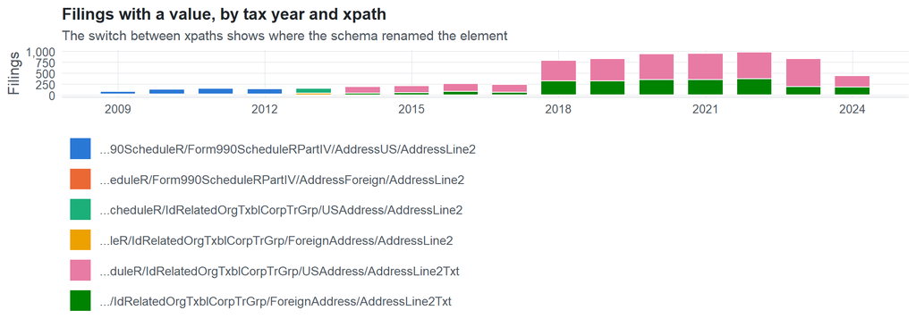

**Table view**

Table view: filings by tax year and series

| Tax year | …90ScheduleR/Form990ScheduleRPartIV/AddressUS/AddressLine2 | …eduleR/Form990ScheduleRPartIV/AddressForeign/AddressLine2 | …cheduleR/IdRelatedOrgTxblCorpTrGrp/USAddress/AddressLine2 | …leR/IdRelatedOrgTxblCorpTrGrp/ForeignAddress/AddressLine2 | …duleR/IdRelatedOrgTxblCorpTrGrp/USAddress/AddressLine2Txt | …/IdRelatedOrgTxblCorpTrGrp/ForeignAddress/AddressLine2Txt |
| --- | --- | --- | --- | --- | --- | --- |
| 2009 | 68 | 19 | 0 | 0 | 0 | 0 |
| 2010 | 111 | 23 | 0 | 0 | 0 | 0 |
| 2011 | 131 | 24 | 0 | 0 | 0 | 0 |
| 2012 | 118 | 25 | 0 | 0 | 0 | 0 |
| 2013 | 0 | 0 | 116 | 38 | 0 | 0 |
| 2014 | 0 | 0 | 0 | 0 | 147 | 42 |
| 2015 | 0 | 0 | 0 | 0 | 165 | 50 |
| 2016 | 0 | 0 | 0 | 0 | 173 | 85 |
| 2017 | 0 | 0 | 0 | 0 | 179 | 61 |
| 2018 | 0 | 0 | 0 | 0 | 475 | 320 |
| 2019 | 0 | 0 | 0 | 0 | 510 | 326 |
| 2020 | 0 | 0 | 0 | 0 | 589 | 356 |
| 2021 | 0 | 0 | 0 | 0 | 596 | 354 |
| 2022 | 0 | 0 | 0 | 0 | 616 | 370 |
| 2023 | 0 | 0 | 0 | 0 | 647 | 190 |
| 2024 | 0 | 0 | 0 | 0 | 267 | 178 |

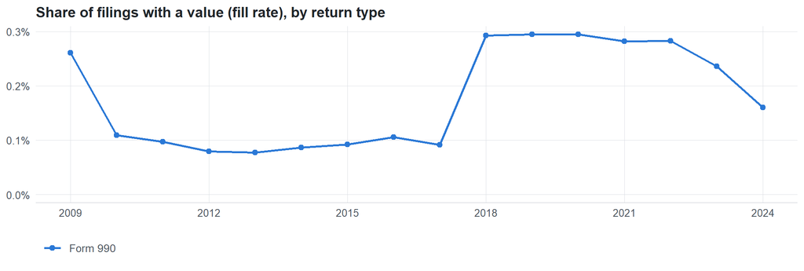

**Table view**

Table view: fill rate

| Tax year | Return type | Filings | All filings | Fill rate |
| --- | --- | --- | --- | --- |
| 2009 | Form 990 | 87 | 33,311 | 0.26% |
| 2010 | Form 990 | 134 | 123,025 | 0.11% |
| 2011 | Form 990 | 155 | 159,504 | 0.10% |
| 2012 | Form 990 | 143 | 179,688 | 0.08% |
| 2013 | Form 990 | 154 | 198,855 | 0.08% |
| 2014 | Form 990 | 189 | 218,619 | 0.09% |
| 2015 | Form 990 | 215 | 233,519 | 0.09% |
| 2016 | Form 990 | 258 | 243,903 | 0.11% |
| 2017 | Form 990 | 240 | 261,612 | 0.09% |
| 2018 | Form 990 | 795 | 271,442 | 0.29% |
| 2019 | Form 990 | 836 | 283,694 | 0.29% |
| 2020 | Form 990 | 945 | 320,342 | 0.29% |
| 2021 | Form 990 | 950 | 336,480 | 0.28% |
| 2022 | Form 990 | 986 | 349,055 | 0.28% |
| 2023 | Form 990 | 837 | 354,768 | 0.24% |
| 2024 | Form 990 | 445 | 277,298 | 0.16% |

## Repeating groups

Table cardinality in the concordance: **many**. 6 of 6 observed xpaths repeat within a filing.

Repeating element each xpath was observed in (from the raw indexed xpath)

| Xpath | Repeating element | Filings (summed over years) |
| --- | --- | --- |
| IRS990ScheduleR/Form990ScheduleRPartIV/AddressForeign/AddressLine2 | (none) | 62 |
| IRS990ScheduleR/Form990ScheduleRPartIV/AddressForeign/AddressLine2 | IRS990ScheduleR/Form990ScheduleRPartIV | 29 |
| IRS990ScheduleR/Form990ScheduleRPartIV/AddressUS/AddressLine2 | (none) | 201 |
| IRS990ScheduleR/Form990ScheduleRPartIV/AddressUS/AddressLine2 | IRS990ScheduleR/Form990ScheduleRPartIV | 227 |
| IRS990ScheduleR/IdRelatedOrgTxblCorpTrGrp/ForeignAddress/AddressLine2 | (none) | 16 |
| IRS990ScheduleR/IdRelatedOrgTxblCorpTrGrp/ForeignAddress/AddressLine2 | IRS990ScheduleR/IdRelatedOrgTxblCorpTrGrp | 22 |
| IRS990ScheduleR/IdRelatedOrgTxblCorpTrGrp/USAddress/AddressLine2 | (none) | 58 |
| IRS990ScheduleR/IdRelatedOrgTxblCorpTrGrp/USAddress/AddressLine2 | IRS990ScheduleR/IdRelatedOrgTxblCorpTrGrp | 58 |
| IRS990ScheduleR/IdRelatedOrgTxblCorpTrGrp/ForeignAddress/AddressLine2Txt | (none) | 108 |
| IRS990ScheduleR/IdRelatedOrgTxblCorpTrGrp/ForeignAddress/AddressLine2Txt | IRS990ScheduleR/IdRelatedOrgTxblCorpTrGrp | 2224 |
| IRS990ScheduleR/IdRelatedOrgTxblCorpTrGrp/USAddress/AddressLine2Txt | (none) | 972 |
| IRS990ScheduleR/IdRelatedOrgTxblCorpTrGrp/USAddress/AddressLine2Txt | IRS990ScheduleR/IdRelatedOrgTxblCorpTrGrp | 3392 |

## Values

| Result | Check | Detail |
| --- | --- | --- |
| ✓ pass | Values are text, not numbers | 0% of values are numeric |
| ⓘ info | No sign of truncation | …/IdRelatedOrgTxblCorpTrGrp/ForeignAddress/AddressLine2Txt: longest value is exactly 35 characters; …duleR/IdRelatedOrgTxblCorpTrGrp/USAddress/AddressLine2Txt: longest value is exactly 35 characters |
| ⓘ info | No dominant boilerplate value | most common value covers 55% of filings: “130 FENCHURCH STREET” |

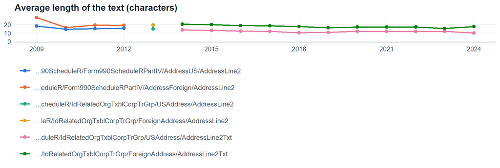

**Table view**

Table view: length and variety by tax year

| Series | Tax year | Filings | Avg length | Max length | Distinct values (approx.) |
| --- | --- | --- | --- | --- | --- |
| …90ScheduleR/Form990ScheduleRPartIV/AddressUS/AddressLine2 | 2009 | 68 | 18 | 27 | 32 |
| …90ScheduleR/Form990ScheduleRPartIV/AddressUS/AddressLine2 | 2010 | 111 | 15 | 32 | 50 |
| …90ScheduleR/Form990ScheduleRPartIV/AddressUS/AddressLine2 | 2011 | 131 | 15 | 34 | 348 |
| …90ScheduleR/Form990ScheduleRPartIV/AddressUS/AddressLine2 | 2012 | 118 | 15 | 32 | 357 |
| …eduleR/Form990ScheduleRPartIV/AddressForeign/AddressLine2 | 2009 | 19 | 28 | 34 | 7 |
| …eduleR/Form990ScheduleRPartIV/AddressForeign/AddressLine2 | 2010 | 23 | 16 | 34 | 17 |
| …eduleR/Form990ScheduleRPartIV/AddressForeign/AddressLine2 | 2011 | 24 | 19 | 34 | 16 |
| …eduleR/Form990ScheduleRPartIV/AddressForeign/AddressLine2 | 2012 | 25 | 19 | 34 | 13 |
| …cheduleR/IdRelatedOrgTxblCorpTrGrp/USAddress/AddressLine2 | 2013 | 116 | 15 | 31 | 253 |
| …leR/IdRelatedOrgTxblCorpTrGrp/ForeignAddress/AddressLine2 | 2013 | 38 | 19 | 34 | 42 |
| …duleR/IdRelatedOrgTxblCorpTrGrp/USAddress/AddressLine2Txt | 2014 | 147 | 14 | 33 | 287 |
| …duleR/IdRelatedOrgTxblCorpTrGrp/USAddress/AddressLine2Txt | 2015 | 165 | 13 | 31 | 239 |
| …duleR/IdRelatedOrgTxblCorpTrGrp/USAddress/AddressLine2Txt | 2016 | 173 | 12 | 35 | 251 |
| …duleR/IdRelatedOrgTxblCorpTrGrp/USAddress/AddressLine2Txt | 2017 | 179 | 12 | 35 | 161 |
| …duleR/IdRelatedOrgTxblCorpTrGrp/USAddress/AddressLine2Txt | 2018 | 475 | 10 | 35 | 199 |
| …duleR/IdRelatedOrgTxblCorpTrGrp/USAddress/AddressLine2Txt | 2019 | 510 | 11 | 35 | 304 |
| …duleR/IdRelatedOrgTxblCorpTrGrp/USAddress/AddressLine2Txt | 2020 | 589 | 12 | 32 | 266 |
| …duleR/IdRelatedOrgTxblCorpTrGrp/USAddress/AddressLine2Txt | 2021 | 596 | 12 | 32 | 232 |
| …duleR/IdRelatedOrgTxblCorpTrGrp/USAddress/AddressLine2Txt | 2022 | 616 | 12 | 32 | 305 |
| …duleR/IdRelatedOrgTxblCorpTrGrp/USAddress/AddressLine2Txt | 2023 | 647 | 12 | 32 | 154 |
| …duleR/IdRelatedOrgTxblCorpTrGrp/USAddress/AddressLine2Txt | 2024 | 267 | 10 | 33 | 234 |
| …/IdRelatedOrgTxblCorpTrGrp/ForeignAddress/AddressLine2Txt | 2014 | 42 | 20 | 35 | 64 |
| …/IdRelatedOrgTxblCorpTrGrp/ForeignAddress/AddressLine2Txt | 2015 | 50 | 20 | 35 | 75 |
| …/IdRelatedOrgTxblCorpTrGrp/ForeignAddress/AddressLine2Txt | 2016 | 85 | 19 | 35 | 96 |
| …/IdRelatedOrgTxblCorpTrGrp/ForeignAddress/AddressLine2Txt | 2017 | 61 | 18 | 35 | 46 |
| …/IdRelatedOrgTxblCorpTrGrp/ForeignAddress/AddressLine2Txt | 2018 | 320 | 17 | 34 | 44 |
| …/IdRelatedOrgTxblCorpTrGrp/ForeignAddress/AddressLine2Txt | 2019 | 326 | 16 | 34 | 111 |
| …/IdRelatedOrgTxblCorpTrGrp/ForeignAddress/AddressLine2Txt | 2020 | 356 | 17 | 35 | 169 |
| …/IdRelatedOrgTxblCorpTrGrp/ForeignAddress/AddressLine2Txt | 2021 | 354 | 17 | 35 | 72 |
| …/IdRelatedOrgTxblCorpTrGrp/ForeignAddress/AddressLine2Txt | 2022 | 370 | 17 | 35 | 135 |
| …/IdRelatedOrgTxblCorpTrGrp/ForeignAddress/AddressLine2Txt | 2023 | 190 | 15 | 35 | 129 |
| …/IdRelatedOrgTxblCorpTrGrp/ForeignAddress/AddressLine2Txt | 2024 | 178 | 18 | 35 | 75 |

Most common values by xpath (all years; long values truncated)

| Series | Value | Filings | Share |
| --- | --- | --- | --- |
| …90ScheduleR/Form990ScheduleRPartIV/AddressUS/AddressLine2 | 501 LEON SULLIVAN WAY | 44 | 10.3% |
| …90ScheduleR/Form990ScheduleRPartIV/AddressUS/AddressLine2 | 76 St Paul 5th floor | 41 | 9.6% |
| …90ScheduleR/Form990ScheduleRPartIV/AddressUS/AddressLine2 | 1644 MILEGROUND | 23 | 5.4% |
| …90ScheduleR/Form990ScheduleRPartIV/AddressUS/AddressLine2 | 100 MICHIGAN AVE NE | 16 | 3.7% |
| …90ScheduleR/Form990ScheduleRPartIV/AddressUS/AddressLine2 | 100 MICHIGAN ST NE | 16 | 3.7% |
| …90ScheduleR/Form990ScheduleRPartIV/AddressUS/AddressLine2 | 1231 EAST BELTLINE NE | 16 | 3.7% |
| …90ScheduleR/Form990ScheduleRPartIV/AddressUS/AddressLine2 | 1840 WEALTHY ST SE | 16 | 3.7% |
| …90ScheduleR/Form990ScheduleRPartIV/AddressUS/AddressLine2 | 2900 BRADFORD STREET NE | 16 | 3.7% |
| …90ScheduleR/Form990ScheduleRPartIV/AddressUS/AddressLine2 | 4100 LAKE DR SE STE 300 | 16 | 3.7% |
| …90ScheduleR/Form990ScheduleRPartIV/AddressUS/AddressLine2 | 425 NORTH MAIN STREET | 16 | 3.7% |
| …90ScheduleR/Form990ScheduleRPartIV/AddressUS/AddressLine2 | 4868 LAKE MICHIGAN DRIVE | 16 | 3.7% |
| …90ScheduleR/Form990ScheduleRPartIV/AddressUS/AddressLine2 | 615 S BOWER | 16 | 3.7% |
| …90ScheduleR/Form990ScheduleRPartIV/AddressUS/AddressLine2 | Bld A Ste 106 | 11 | 2.6% |
| …90ScheduleR/Form990ScheduleRPartIV/AddressUS/AddressLine2 | 8 SOUTH MICHIGAN AVE | 9 | 2.1% |
| …90ScheduleR/Form990ScheduleRPartIV/AddressUS/AddressLine2 | 70 DUBOIS STREET | 6 | 1.4% |
| …90ScheduleR/Form990ScheduleRPartIV/AddressUS/AddressLine2 | PO BOX 278 | 5 | 1.2% |
| …90ScheduleR/Form990ScheduleRPartIV/AddressUS/AddressLine2 | SUITE 200 | 5 | 1.2% |
| …90ScheduleR/Form990ScheduleRPartIV/AddressUS/AddressLine2 | PO BOX 10 | 4 | 0.9% |
| …90ScheduleR/Form990ScheduleRPartIV/AddressUS/AddressLine2 | SUITE 1 | 4 | 0.9% |
| …90ScheduleR/Form990ScheduleRPartIV/AddressUS/AddressLine2 | Suite 1500 | 3 | 0.7% |
| …90ScheduleR/Form990ScheduleRPartIV/AddressUS/AddressLine2 | 107 LATHROP ST | 3 | 0.7% |
| …90ScheduleR/Form990ScheduleRPartIV/AddressUS/AddressLine2 | 1217 CLIFFORD AVE | 3 | 0.7% |
| …90ScheduleR/Form990ScheduleRPartIV/AddressUS/AddressLine2 | 1304 ROUTE 9 | 3 | 0.7% |
| …90ScheduleR/Form990ScheduleRPartIV/AddressUS/AddressLine2 | 131 READING ST | 3 | 0.7% |
| …90ScheduleR/Form990ScheduleRPartIV/AddressUS/AddressLine2 | 1827 FREEDOM ROAD | 3 | 0.7% |
| …90ScheduleR/Form990ScheduleRPartIV/AddressUS/AddressLine2 | 2150 ELDO ROAD | 3 | 0.7% |
| …90ScheduleR/Form990ScheduleRPartIV/AddressUS/AddressLine2 | 2559 ROUTE 88 | 3 | 0.7% |
| …90ScheduleR/Form990ScheduleRPartIV/AddressUS/AddressLine2 | 328 BLUFF STREET | 3 | 0.7% |
| …90ScheduleR/Form990ScheduleRPartIV/AddressUS/AddressLine2 | 436 BUTLER STREET | 3 | 0.7% |
| …90ScheduleR/Form990ScheduleRPartIV/AddressUS/AddressLine2 | 4955 SPRING GROVE AVE | 3 | 0.7% |

First rows shown.

## Examples

| Tax year | Return | Xpath | Organization | Value | Source |
| --- | --- | --- | --- | --- | --- |
| 2024 | 990 | IRS990ScheduleR/IdRelatedOrgTxblCorpTrGrp/ForeignAddress/AddressLine2Txt | St Francis Hospital Inc | Clanwilliam Place | [XML](https://gt990datalake-rawdata.s3.amazonaws.com/EfileData/XmlFiles/202543219349302599_public.xml) |
| 2024 | 990 | IRS990ScheduleR/IdRelatedOrgTxblCorpTrGrp/USAddress/AddressLine2Txt | St Francis Hospital Inc | Ste 200 | [XML](https://gt990datalake-rawdata.s3.amazonaws.com/EfileData/XmlFiles/202543219349302599_public.xml) |
| 2023 | 990 | IRS990ScheduleR/IdRelatedOrgTxblCorpTrGrp/ForeignAddress/AddressLine2Txt | Harvard Real Estate - Allston Inc | PO BOX 1348 | [XML](https://gt990datalake-rawdata.s3.amazonaws.com/EfileData/XmlFiles/202541359349307959_public.xml) |
| 2023 | 990 | IRS990ScheduleR/IdRelatedOrgTxblCorpTrGrp/USAddress/AddressLine2Txt | ARIZONA PUBLIC INTEREST RESEARCH GROUP INC | Suite 720 | [XML](https://gt990datalake-rawdata.s3.amazonaws.com/EfileData/XmlFiles/202531359349313413_public.xml) |
| 2022 | 990 | IRS990ScheduleR/IdRelatedOrgTxblCorpTrGrp/ForeignAddress/AddressLine2Txt | CORNERSTONE ASSISTED LIVING INC | 130 FENCHURCH STREET | [XML](https://gt990datalake-rawdata.s3.amazonaws.com/EfileData/XmlFiles/202401329349300600_public.xml) |
| 2022 | 990 | IRS990ScheduleR/IdRelatedOrgTxblCorpTrGrp/USAddress/AddressLine2Txt | Baptist Hospital of Miami Inc | Suite 135 | [XML](https://gt990datalake-rawdata.s3.amazonaws.com/EfileData/XmlFiles/202442269349301264_public.xml) |
| 2021 | 990 | IRS990ScheduleR/IdRelatedOrgTxblCorpTrGrp/ForeignAddress/AddressLine2Txt | St John Providence | 130 FENCHURCH STREET | [XML](https://gt990datalake-rawdata.s3.amazonaws.com/EfileData/XmlFiles/202311329349304191_public.xml) |
| 2021 | 990 | IRS990ScheduleR/IdRelatedOrgTxblCorpTrGrp/USAddress/AddressLine2Txt | St John Providence | PO BOX 45998 | [XML](https://gt990datalake-rawdata.s3.amazonaws.com/EfileData/XmlFiles/202311329349304191_public.xml) |
| 2020 | 990 | IRS990ScheduleR/IdRelatedOrgTxblCorpTrGrp/ForeignAddress/AddressLine2Txt | Saint Thomas Regional Hospitals | 130 FENCHURCH STREET | [XML](https://gt990datalake-rawdata.s3.amazonaws.com/EfileData/XmlFiles/202241349349302439_public.xml) |
| 2020 | 990 | IRS990ScheduleR/IdRelatedOrgTxblCorpTrGrp/USAddress/AddressLine2Txt | Nashville Symphony Association | 40 BURTON HILLS BLVD STE 300 | [XML](https://gt990datalake-rawdata.s3.amazonaws.com/EfileData/XmlFiles/202231649349300423_public.xml) |
| 2019 | 990 | IRS990ScheduleR/IdRelatedOrgTxblCorpTrGrp/ForeignAddress/AddressLine2Txt | ASCENSION STANDISH HOSPITAL | 130 FENCHURCH STREET | [XML](https://gt990datalake-rawdata.s3.amazonaws.com/EfileData/XmlFiles/202111339349302336_public.xml) |
| 2019 | 990 | IRS990ScheduleR/IdRelatedOrgTxblCorpTrGrp/USAddress/AddressLine2Txt | ASCENSION STANDISH HOSPITAL | SUITE 450 | [XML](https://gt990datalake-rawdata.s3.amazonaws.com/EfileData/XmlFiles/202111339349302336_public.xml) |

## Reviewer checklist

- The definition matches the form line and instructions for every xpath’s schema years.
- Every xpath pooled here measures the same thing on the 990 and 990-EZ (close enough for analysis).
- The coverage chart has no unexplained gaps or jumps between tax years.
- Each open flag is fixed, or accepted with a note in validation_log.csv.
- Values answer the question on the form line (not another line’s explanation).
- Boilerplate such as ‘See Schedule O’ or ‘N/A’ is expected here, or should be treated as missing.
- Text that is really a number or a code is flagged for a different data type.

Record the review as a row in `inst/extdata/src/validation_log.csv` (variable_name, reviewer, date, status, note). Evidence built 2026-09-23 17:09:04 MST from the ef2 DuckDB builds (tax years 2009–2024).